# Exploration of Eating habit: Age, Income, Grades, and Ethnicity

## Diane G & Huiyu Q

# Introduction & Motivation

It is common to see college students who complain about the quality of foods provided by school-owned dining services, which leads people to wonder whether students will turn away from school dining options to eating at restaurants outside. Apparently, there are more variables that could have an impact on students’ eating habits. These variables include the year in college, employment status, grades, and identity. The reasons why these variables matter will be examined in the later parts of this project. The study that will be conducted could potentially lead to useful insights for restaurant business owners. In detail, those who have plans to enter the restaurant business could better find an optimal location for their restaurant businesses. The rent or price of commercial property near the school is usually more expensive. The restaurant owner could use the data in this research to determine whether it’s worth it to rent or buy the commercial property for opening up a restaurant with the premium.

## Problem Addressed & Hypothesis

#### Primary Question:

How often do you eat off campus per week? (Q25)

#### Variable Questions:

- What year are you at Emory? (Q1)
- Do you currently have a job? (Q66)
- What is your cumulative GPA up to this point? (Q8)
- What ethnicity do you identify as? (Q5)

#### Hypothesis:

- Senior students will have a greater mean of eating outside than other groups of students
- Students who have a job will have a greater means of eating outside than students who don’t have a job
- Students with a lower GPA will have a higher mean of eating outside
- Students who identify as Asian will have a greater mean of eating outside than other groups of students

#### The purpose of this project is to analyze the possible factors that contribute to Econ 220 students’ frequency of eating outside.

## Literature Support

We expect that higher-year students tend to eat more often off-campus compared to lower-grade students. In other words, higher-year students (junior and senior) and students that have a job are more likely to eat off-campus, which means that the juniors and seniors’ mean of the frequency of eating off campus would be significantly greater than the number for the freshmen and sophomores.

According to the research published by Jean Adams in 2015, 27.1% of adults and 19.0% of children at least eat out more than once a week.(Adams) Although the researchers didn’t determine whether there is a positive relationship between age and frequency of eating outside, it’s reasonable to suspect there is such a relationship.

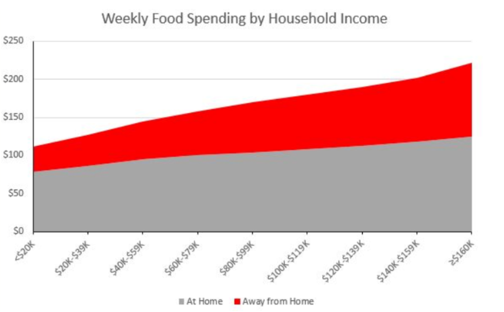

According to this graph, we can tell that there is a positive relationship between income and the proportion of food spending on food away from home, which means that people probably tend to eat out more often as their income increases. Inspired by this observation, we realized that higher grade students in college are more likely to find paid internships/part-time jobs than the lower grade students do. Therefore, it is likely that the higher grade students would eat out more often than the lower grade students.

In 2014, Marte from the Washington Post conducted a study to research the relationship between grades and incomes. In the research, Marte discovered that for a one-point increase in a person's high school GPA, average annual earnings in adulthood increased by about 12 percent for men and about 14 percent for women. We suspect that there is a positive relationship between income and frequency of eating out, but we have not proven the correlation between them. It is possible that those who have higher grades, who happen to have higher incomes, tend to eat out more often. Therefore, we decide to verify whether there is a relationship between grades and eating out.

According to Jim from CDC, Multivariate adjusted minutes per day spent on primary eating and drinking were 66.4 for noncitizens, 66.5 for naturalized citizens, and 60.1 for US-born individuals. (Jim) Due to this result, we would assume that the difference between eating time is due to eating at home and eating out. Therefore, it is reasonable to assume that there is a relationship between the frequency of eating out and ethnicities.

# Data Cleaning

```python
#Import other necesarry packages
import numpy as np
import pandas as pd
import matplotlib.pyplot as plt
import seaborn as sns
import scipy.stats as stats
from scipy.stats import ttest_ind
import statsmodels.api as sm
from statsmodels.formula.api import ols
```

```python
#Load the dataset
data = pd.read_csv("/Users/diane3426/Desktop/Lab 220/Econ220DataF21.csv")
```

```python
#Summary of the dataset
#Selecting variables
data = data[['year','Ethnicity','GPA','q25','q66']]
```

```python
#Find missing data in each variables and remove unwanted missing data
data['year'].isna().sum()
data['Ethnicity'].isna().sum()
data['GPA'].isna().sum()
data['q25'].isna().sum()
data['q66'].isna().sum()
data = data.dropna()

#Cleaning variable year
#Use .replace to replace different ways of describing grade level as numerical number from 1 to 4
#Change variable type to 'category'
data['year'] = data['year'].str.strip()
data['year'] = data['year'].replace("2024", "2", regex=True).replace("2023", "2", regex=True).replace("3rd year", "3", regex=True).replace("2nd", "2", regex=True).replace("2 year", "2", regex=True).replace("Sophmore", "2", regex=True).replace("Sophomore", "2", regex=True).replace("3rd", "3", regex=True).replace("Senior", "4", regex=True).astype('category')
data['year'].value_counts(dropna=False)

#Cleaning variable Ethnicity
data['Ethnicity'] = data['Ethnicity'].replace("No answer text provided.", "More than one race.", regex=True).astype('category')
#data['Ethnicity'].value_counts(dropna=False)

#Cleaning variable GPA
data['GPA'] = data['GPA'].str.strip()
data['GPA'] = data['GPA'].replace("3,1", "3.1", regex=True).replace("3.76\n\nDon't have a high school GPA", "3.76", regex=True).replace("3,85", "3.85", regex=True).replace("3,94", "3.94", regex=True).replace("3.3, 3.98", "3.3", regex=True).replace("Sophmore", "2", regex=True).astype('float')
#data['GPA'].value_counts(dropna=False)


#Cleaning variable q25
data['q25'] = data['q25'].replace("0.25", "0", regex=True).replace("2-3 times", "3", regex=True).astype('float')
#data['q25'].value_counts(dropna=False)

#Cleaning variable q66
data['q66'] = data['q66'].astype('category')
#data['q66'].value_counts(dropna=False)
```

```python
#Change variables' name
data1 = data.rename(columns= {'year': 'Year',
                               'q25': 'Frequency',
                               'q66': 'Job'})
```

# Dataset Analysis

Prior to any data analysis, it is important to understand our sample population. In our research, three sets of categorical variables and two sets of numerical variables are involved. The two sets of categorical variables are students’ grade level, whether they have a job, and students’ ethnicity. The numerical variable is the frequency of eating out and students’ GPA score.

## Summary Statistics

Since we only have two varibles that are counted as numerical variable, only the frequency of students eating out and the students' GPA scores are included in this part of analysis.

```python
data1[["Frequency","GPA"]].describe()
```

|  | Frequency | GPA |
| --- | --- | --- |
| count | 100.000000 | 100.000000 |
| mean | 4.170000 | 3.658320 |
| std | 4.481285 | 0.302042 |
| min | 0.000000 | 2.500000 |
| 25% | 1.000000 | 3.500000 |
| 50% | 3.000000 | 3.700000 |
| 75% | 6.000000 | 3.900000 |
| max | 21.000000 | 4.000000 |

## Visual Examination of Dataset

### Students' Grade Level vs. Frequency of Eating Out

```python
# Histogram: Year vs. Frequency
year_frequency = data1.pivot_table(values=["Frequency"], index="Year", aggfunc=[np.mean])
year_frequency.reset_index(inplace=True)
year_frequency.columns = list(map("_".join, year_frequency.columns))
year_frequency
```

|  | Year_ | mean_Frequency |
| --- | --- | --- |
| 0 | 1 | 8.000000 |
| 1 | 2 | 2.775000 |
| 2 | 3 | 5.095238 |
| 3 | 4 | 3.923077 |
| 4 | 5 | 8.500000 |

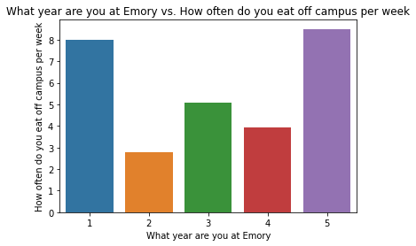

```python
ax =sns.barplot(x="Year_",
                y="mean_Frequency",
                data=year_frequency).set(title ="What year are you at Emory vs. How often do you eat off campus per week", xlabel = "What year are you at Emory", ylabel =  "How often do you eat off campus per week")
```

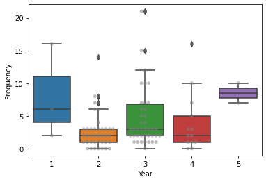

```python
# Boxplot: Year vs. Frequency
ax = sns.boxplot(x="Year", y="Frequency",
                 data=data1)
ax = sns.swarmplot(x="Year", y="Frequency",
                   data=data1, color="grey", alpha=0.5)
```

- According to the data and graph we obtained, the average frequency of eating out is higher for the students in fifth grade in college, but there are only two students in fifth grade in the sample. Since the sample size in the fifth grade student is relative small, it might not be a great representative sample reflecting the population mean. Therefore, it is more reasonable to interpret it as the first year students eat out most frequently among the five group. At the first glance, the distribution for this graph isn’t normally distributed. However, the sample size is relatively large, so the result that we derived is still meaningful.

### Whether A Student Having A Job vs. Frequency of Eating Out

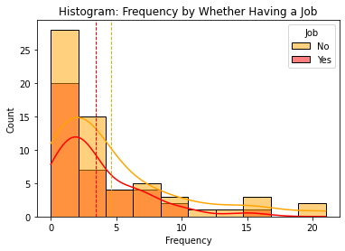

```python
# Frequency distribution by Whether having a job
ax = sns.histplot(x = data1.Frequency, hue = data1.Job,palette = ['orange','red'], kde=True, alpha=0.5)
plt.axvline(data1[data1['Job']=='Yes'].
            Frequency.mean(), color='red',
            linestyle='dashed', linewidth=1)
plt.axvline(data1[data1['Job']=='No'].
            Frequency.mean(), color='orange',
            linestyle='dashed', linewidth=1)
#ax = sns.violinplot(x="gender", y="weight", data=BirthdataNC, palette="Blues")
ax.set_title("Histogram: Frequency by Whether Having a Job"); # the colon here eliminates the output message try without it.
```

- Based on the histogram we obtained from the graph, the distribution on frequency of eating out is not normally distributed. Instead, the distribution is heavily right-skewed, which indicates that it is more likely for students to have a lower frequency of eating out compared to having higher frequency. In addition, the distribution patterns for both employed students and unemployed students are similar, which might not lead to meaningful results here.

### Students' GPA Scores vs. Frequency of Eating Out

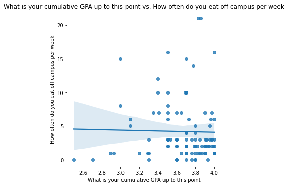

```python
# Scatter Plot: GPA vs. Frequency
sns.lmplot(x="GPA", y="Frequency", data=data1).set(title ="What is your cumulative GPA up to this point vs. How often do you eat off campus per week",
                                      xlabel = "What is your cumulative GPA up to this point",
                                      ylabel =  "How often do you eat off campus per week");
```

- According to the graph we obtained from the data, because the regression line fit is not explaining the sample point in the group, there might not be a significant relationship between GPA and frequency of eating out.

### Students' Ethnicity vs. Frequency of Eating Out

```python
# Table: Ethnicity vs. Frequency mean
ethnicity_frequency = data1.pivot_table(values=["Frequency"], index="Ethnicity", aggfunc=[np.mean])
ethnicity_frequency.reset_index(inplace=True)
ethnicity_frequency.columns = list(map("_".join, ethnicity_frequency.columns))
ethnicity_frequency
```

|  | Ethnicity_ | mean_Frequency |
| --- | --- | --- |
| 0 | Asian | 5.071429 |
| 1 | Black or African American. | 2.500000 |
| 2 | Hispanic or Latino. | 2.000000 |
| 3 | More than one race. | 5.428571 |
| 4 | White or Caucasian | 2.730769 |

[output not shown]

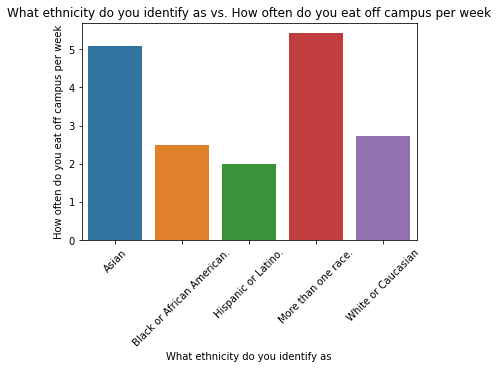

```python
# Histogram: Ethnicity vs. Frequency
ax =sns.barplot(x="Ethnicity_",
                y="mean_Frequency",
                data=ethnicity_frequency).set(title ="What ethnicity do you identify as vs. How often do you eat off campus per week", xlabel = "What ethnicity do you identify as", ylabel =  "How often do you eat off campus per week")
plt.xticks(rotation=45)
```

[output not shown]

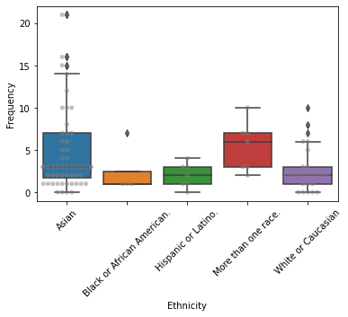

```python
# Boxplot: Ethnicity vs. Frequency
ax = sns.boxplot(x="Ethnicity", y="Frequency",
                 data=data1)
ax = sns.swarmplot(x="Ethnicity", y="Frequency",
                   data=data1, color="grey", alpha=0.5)
plt.xticks(rotation=45)
```

- Based on the graph we obtained, the group of students who identified with more than one race has the highest frequency to eat out. The students who are identified as Asians have the second highest frequency of eating out. But since the sample size for more than one race is relatively small(n=7), it might not be a great representative sample reflecting the population mean. This observation suggests that opening up restaurants that provide Asian cuisine might help the businesses to succeed.

# Analysis Confidence Intervals and Testing

In this project, the analysis on confidence intervals and testing are using a=0.05 as the level of signifance.

### ANOVA Test

Problem addressed: What year are you at Emory vs. How often do you eat off campus per week

- Null Hypothesis: there is no difference in means among the five groups of the students’ grade
- Alternative Hypothesis: The means for the four groups of students’ grades are different

```python
year_1 = data1[data1['Year']=='1']
year_2 = data1[data1['Year']=='2']
year_3 = data1[data1['Year']=='3']
year_4 = data1[data1['Year']=='4']
year_5 = data1[data1['Year']=='5']

# stats f_oneway functions takes the groups as input and returns ANOVA F and p value
fvalue, pvalue = stats.f_oneway(year_1['Frequency'], year_2['Frequency'], year_3['Frequency'],year_4['Frequency'],year_5['Frequency'])


print("\nANOVA Test for differences in frequency by grade of students:\n P-Value:{0}\n F-Statistic:{1}\n".
        format(round(pvalue,3),
               round(fvalue,3)))
```

```
ANOVA Test for differences in frequency by grade of students:
 P-Value:0.041
 F-Statistic:2.599
```

- In this case, because there is a total of 100 sample point(n=100) and there are five groups of students' grade level, the degree of freedom 1 equal 4(DF1 = NbGroup – 1) and the degree of freedom 2 equal 95(DF2 = N – NbGroup). Thus, based on significant level of 0.05(a=0.05), the critical value in this case equal 2.4675. Since F-value of 2.599 is greater than the critial value of 2.4675, and p-value is less than 0.05, We have statistically significant evidence to show that there is a difference in students'grade level of frequency of eating out.

### Two Sample T Test

Problem addressed: Do you currently have a job(YES or NO) vs. How often do you eat off campus per week

- Null Hypothesis: the mean of eating off campus per week for students with a job and without a job is equal
- Alternative Hypothesis: the mean of eating off campus per week for students with a job and without a job is not equal

```python
job_y = data1[data1['Job']=='Yes']
job_n = data1[data1['Job']=='No']

print('\nDifference in means between with a job vs without a job\n',
      round(data1.groupby('Job')['Frequency'].mean()[0]-
            data1.groupby('Job')['Frequency'].mean()[1],5))

#run independent sample T-Test
tStat, pValue = stats.ttest_ind(job_y['Frequency'],
                                job_n['Frequency'])

print("\nT-test for differences in Frequency by whether having a job:\n P-Value:{0}\n T-Statistic:{1}\n".
        format(round(pValue,3),
               round(tStat,3)))
```

```
Difference in means between with a job vs without a job
 1.16553

T-test for differences in Frequency by whether having a job:
 P-Value:0.208
 T-Statistic:-1.266
```

### Linear Regression Test

- Null Hypothesis: there is no relationship between students’ GPA scores and students’ frequency of eating outside
- Alternative Hypothesis: there is a relationship between students’ GPA scores and students’ frequency of eating outside

```python
# Linear Regression using statsmodels
model = sm.OLS.from_formula('Frequency ~ GPA', data = data1)
results = model.fit()
print(results.summary())
```

```
                            OLS Regression Results
==============================================================================
Dep. Variable:              Frequency   R-squared:                       0.000
Model:                            OLS   Adj. R-squared:                 -0.010
Method:                 Least Squares   F-statistic:                   0.04433
Date:                Sun, 05 Dec 2021   Prob (F-statistic):              0.834
Time:                        17:45:40   Log-Likelihood:                -291.36
No. Observations:                 100   AIC:                             586.7
Df Residuals:                      98   BIC:                             591.9
Df Model:                           1
Covariance Type:            nonrobust
==============================================================================
                 coef    std err          t      P>|t|      [0.025      0.975]
------------------------------------------------------------------------------
Intercept      5.3242      5.500      0.968      0.335      -5.590      16.239
GPA           -0.3155      1.498     -0.211      0.834      -3.289       2.658
==============================================================================
Omnibus:                       47.350   Durbin-Watson:                   1.619
Prob(Omnibus):                  0.000   Jarque-Bera (JB):              107.496
Skew:                           1.872   Prob(JB):                     4.55e-24
Kurtosis:                       6.433   Cond. No.                         48.1
==============================================================================

Notes:
[1] Standard Errors assume that the covariance matrix of the errors is correctly specified.
```

### ANOVA Test

Problem addressed: What ethnicity do you identify as vs. How often do you eat off campus per week

- Null Hypothesis: there is no difference in means among different ethnicity
- Alternative Hypothesis: The means for different ethnicity of students are different

```python
race_1 = data1[data1['Ethnicity']=='Asian']
race_2 = data1[data1['Ethnicity']=='Black or African American.']
race_3 = data1[data1['Ethnicity']=='Hispanic\xa0or Latino.']
race_4 = data1[data1['Ethnicity']=='More than one race.']
race_5 = data1[data1['Ethnicity']=='White or Caucasian']

fvalue, pvalue = stats.f_oneway(race_1['Frequency'], race_2['Frequency'], race_3['Frequency'],race_4['Frequency'],race_5['Frequency'])

print("\nANOVA Test for differences in frequency by ethnicity of students:\n P-Value:{0}\n F-Statistic:{1}\n".
        format(round(pvalue,3),
               round(fvalue,3)))
```

```
ANOVA Test for differences in frequency by ethnicity of students:
 P-Value:0.1
 F-Statistic:2.002
```

# Conclusion & Summary

#### Do you currently have a job(YES or NO) vs. How often do you eat off campus per week

- Our result does not shows a significant relationship of frequency of eating outside between student having and not having a job. Although it is more resonable to assume that student who have a job is more likely to eat outside because of having income resource, it is also possible that a student with a job is more likely to distribute their wealth based on individual financial planning and thus cooking by oneself other than eating outside.

- Our result indicates that there is not enough evidence to suggest that there is a relationship between students’ GPA scores and students’ frequency of eating outside. In other words, whether a student like to eat outside or at school does not play role in determinaing individual's GPA scores.

# Reference

Jayson Lusk. “How Food Spending Varies with Income.” Jayson Lusk, Jayson Lusk, 21 Sept. 2017, jaysonlusk.com/blog/2017/9/20/how-food-spending-varies-with-income.

“Time Spent Eating, by Immigrant Status, Race/Ethnicity, and Length of Residence in the United States.” Centers for Disease Control and Prevention, Centers for Disease Control and Prevention, 25 Nov. 2020, www.cdc.gov/pcd/issues/2020/20_0122.htm.

Adams, Jean, et al. “Frequency and Socio-Demographic Correlates of Eating Meals out and Take-Away Meals at Home: Cross-Sectional Analysis of the UK National Diet and Nutrition Survey, Waves 1–4 (2008–12).” International Journal of Behavioral Nutrition and Physical Activity, BioMed Central, 16 Apr. 2015, ijbnpa.biomedcentral.com/articles/10.1186/s12966-015-0210-8.

Marte, Jonnelle. “Here's How Much Your High School Grades Predict Your Future Salary.” The Washington Post, WP Company, 25 Nov. 2021,

```python
!jupyter nbconvert --to html research_project_Diane_Harvey.ipynb
```

```
[NbConvertApp] Converting notebook research_project_Diane_Harvey.ipynb to html
[NbConvertApp] Writing 1021359 bytes to research_project_Diane_Harvey.html
```